# R Notebook

## 02. Statistical analysis

### Task: Which statistical test should I use to compare the groups ?

In order to know about which statistical test to use (e.g. parametric or non-parametric), we first need to check it the data is normaly distributed.

#### Is my data normally distributed ?

Before applying statistical tests, especially parametric tests such as the t-test, ANOVA, or linear regression, it is important to assess whether your data follows a normal distribution. These tests rely on the assumption of normality for accurate results.

#### Visual inspection

```r
# In order to start a new notebook, let's re-import the data

neurites <- read.csv(file="../../data/03_neurites_synthetic.csv")
```

#### Plot Histograms of Data

A quick way to check if data is normally distributed is by visually inspecting histograms.

A histogram is a graphical way to visualize the distribution of a numerical dataset by grouping data values into equal-width intervals (called bins) and displaying the frequency or density of observations in each bin as adjacent bars. The x-axis represents the range of data values divided into these bins, while the y-axis shows how many data points fall within each bin (or their relative proportion). The overall shape of the histogram—whether symmetric, skewed, or multimodal—reveals key features of the data’s distribution, such as its central tendency, spread, and the presence of outliers, making it a fundamental tool for exploratory data analysis.

```r
neurites
```

| control | condition_1 | condition_2 |
| --- | --- | --- |
| 0.06372999 | 0.7305269 | 1.09728997 |
| 0.10308265 | 1.1828578 | 3.92038951 |
| 0.99902660 | 0.7414197 | 5.52390681 |
| 0.60876101 | 0.6742225 | 7.15188387 |
| 0.63159041 | 1.0256576 | 7.16780066 |
| 0.39914599 | 1.4141315 | 7.61176463 |
| 0.70256457 | 0.9060978 | 6.45179316 |
| 0.10291603 | 0.8720033 | 0.08549482 |
| 0.73953168 | 0.4106907 | 0.24295711 |
| 0.32652134 | 1.0834832 | 1.00254557 |

[output cut: 10 more lines]

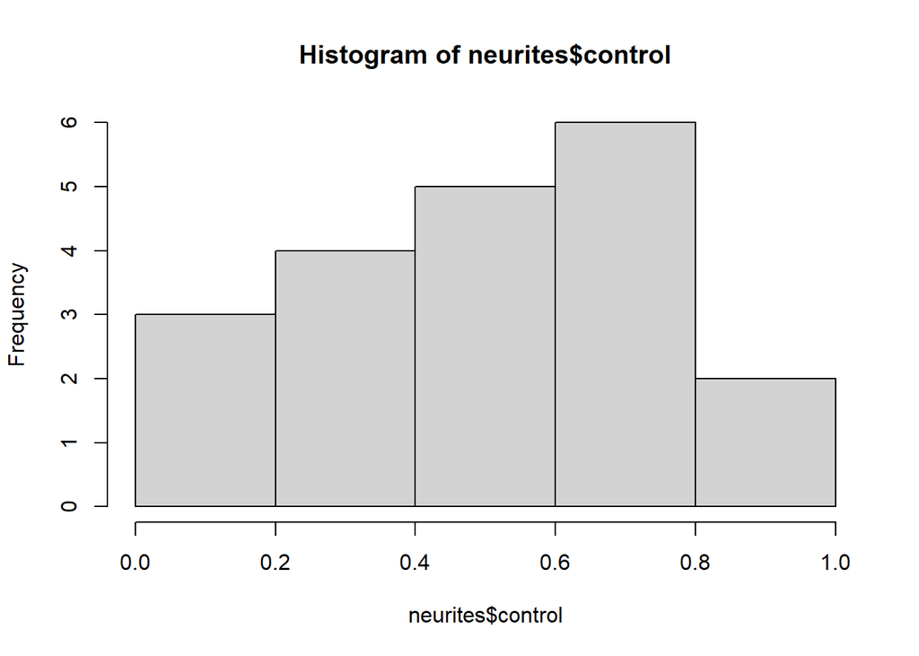

```r
hist(neurites$control)
```

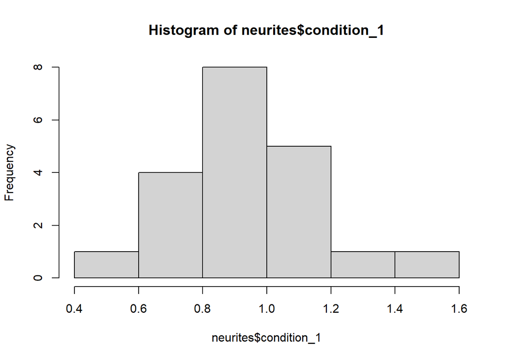

```r
hist(neurites$condition_1)
```

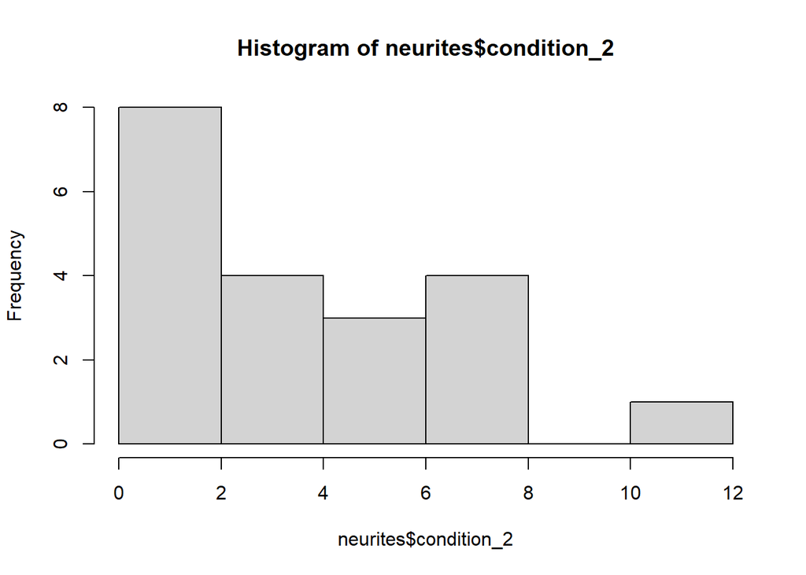

```r
hist(neurites$condition_2,breaks=5)
```

**Explanation:** Histograms allow us to visually assess the shape of the data. If the distribution resembles a bell-shaped curve, the data might be normally distributed.

*Exercise: Experiment with the breaks= parameter in the hist() function to see how changing the number of bins affects the appearance of the histogram.*

#### Numerical method

Numerically, a normal distribution typically has its mean and median very close to each other. Let’s calculate and compare these values.

*Exercise: Calculate the median and mean for each column of the neurites dataset.*

```r
# Your code here
```

#### QQ Plot (Quantile-Quantile Plot)

A more formal visual inspection for normality is the Q-Q plot, which compares the observed data to a theoretical normal distribution.

- It compares quantiles of your sample data to quantiles of a theoretical distribution (e.g. normal).
- If the data come from that distribution, the points will fall roughly along a straight line.

A QQ plot (quantile–quantile plot) visually assesses whether a dataset follows a particular theoretical distribution, most commonly the normal distribution. It does this by sorting the data, calculating the corresponding theoretical quantiles of the chosen distribution—usually after estimating its parameters such as mean and standard deviation from the data—and plotting the sample quantiles against these theoretical quantiles. If the data are consistent with the theoretical distribution, the points fall roughly along a straight diagonal line; systematic deviations, such as curves or S-shapes, reveal heavy or light tails, skewness, or outliers. In this way, a QQ plot provides a quick, intuitive check of distributional assumptions without performing a formal statistical test.

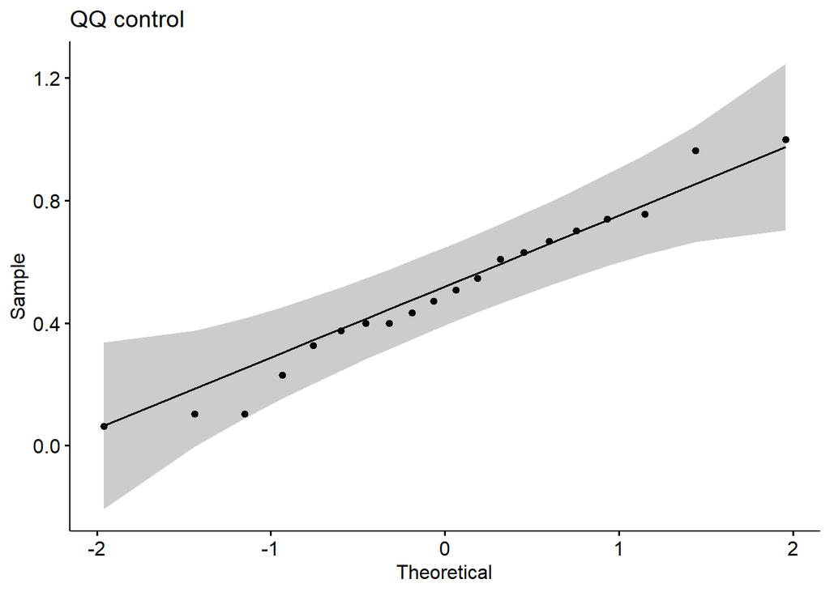

```r
# Load ggpubr library for creating QQ plots
library(ggpubr)
# Create QQ plots for each condition
ggqqplot(neurites$control,title = 'QQ control')
```

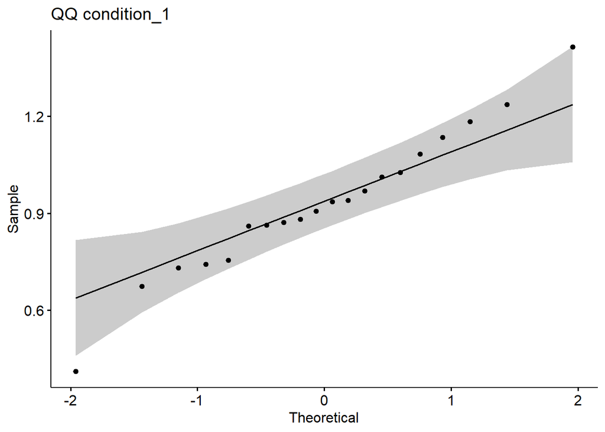

```r
ggqqplot(neurites$condition_1,title = 'QQ condition_1')
```

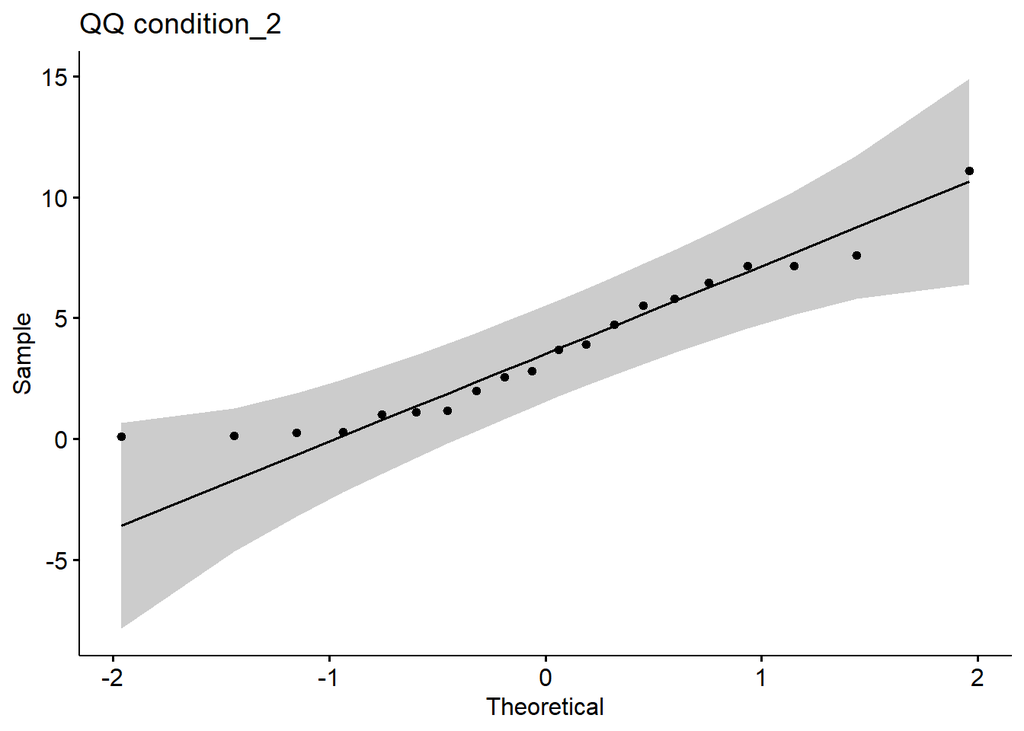

```r
ggqqplot(neurites$condition_2,title = 'QQ condition_2')
```

Explanation: The Q-Q plot helps visualize how closely the data matches the normal distribution. Deviations from the straight line suggest departures from normality.

For more details on Q-Q plots, refer to this [resource](http://www.sthda.com/english/wiki/qq-plots-quantile-quantile-plots-r-base-graphs)

#### Shapiro-Wilk Test for Normality

A formal statistical test for normality is the Shapiro-Wilk test. It is widely recommended for small sample sizes and is based on the correlation between the data and a normal distribution.

The Shapiro–Wilk test is a statistical test used to assess whether a dataset is consistent with a normal distribution. It works by comparing the order statistics (sorted values) of the sample to the expected order statistics from a perfectly normal distribution with the same mean and variance, calculating a W statistic that measures how closely the two sets of quantiles align. A W value near 1 indicates strong agreement with normality, while smaller values signal departures such as skewness or heavy tails. The test provides a p-value: if the p-value is less than a chosen significance level (commonly 0.05), you reject the null hypothesis of normality, concluding the data are unlikely to be normally distributed.

The Shapiro–Wilk test, while powerful for detecting departures from normality, is sensitive to several factors that can limit its reliability. It is highly sensitive to sample size: with very large samples, even tiny and practically irrelevant deviations from normality can yield a significant p-value, while with small samples (e.g. fewer than 10 observations) the test has low power and may fail to detect substantial non-normality. The test also assumes independent observations and can give misleading results if there are correlations or repeated measures. Moreover, it is affected by outliers, which can strongly lower the W statistic and trigger a false rejection of normality. Because of these vulnerabilities, it is recommended to interpret Shapiro–Wilk results alongside graphical checks such as QQ plots or histograms and to consider the practical importance of any detected deviations rather than relying on the p-value alone.

```r
shapiro.test(neurites$control)
```

```
##
##  Shapiro-Wilk normality test
##
## data:  neurites$control
## W = 0.97049, p-value = 0.7652
```

```r
shapiro.test(neurites$condition_1)
```

```
##
##  Shapiro-Wilk normality test
##
## data:  neurites$condition_1
## W = 0.9803, p-value = 0.9379
```

```r
shapiro.test(neurites$condition_2)
```

```
##
##  Shapiro-Wilk normality test
##
## data:  neurites$condition_2
## W = 0.92259, p-value = 0.1111
```

**Explanation:** If the p-value is less than 0.05, it suggests that the data is not normally distributed. However, this test is sensitive to large sample sizes, where small deviations from normality might lead to significant results.

For more details on the Shapiro-Wilk test, see this resource [link](http://www.sthda.com/english/wiki/normality-test-in-r)

## *Exercise: Based on all of the above tests, discuss whether the data is normally distributed.*

#### Example of Non-Normally Distributed Data

If you mix several normal distributions, the result is often a non-normal distribution. Let’s test this concept by merging the three conditions together.

```r
# Merge data from all conditions into one vector
mixed.data <- unname(unlist(neurites))
head(mixed.data)
```

```
## [1] 0.06372999 0.10308265 0.99902660 0.60876101 0.63159041 0.39914599
```

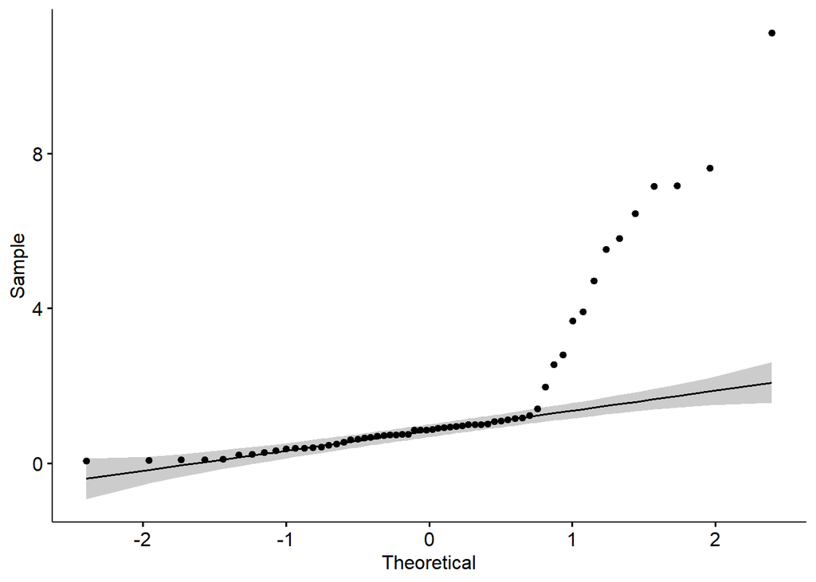

```r
# Plot QQ plot and perform Shapiro-Wilk test on the merged data
ggqqplot(mixed.data)
```

```r
shapiro.test(mixed.data)
```

```
##
##  Shapiro-Wilk normality test
##
## data:  mixed.data
## W = 0.64966, p-value = 1.066e-10
```

Explanation: By mixing distributions, we create data that is likely non-normal. You can use the Q-Q plot and the Shapiro-Wilk test to confirm this.

#### F-Test to Compare Variances

Because the test assumes independent, normally distributed data in both groups, strong skewness or outliers can distort the result, so it’s often combined with visual checks like histograms or boxplots.

```r
# Compare variances between conditions using F-test
var.test(neurites$control, neurites$condition_1)
```

```
##
##  F test to compare two variances
##
## data:  neurites$control and neurites$condition_1
## F = 1.4325, num df = 19, denom df = 19, p-value = 0.4406
## alternative hypothesis: true ratio of variances is not equal to 1
## 95 percent confidence interval:
##  0.5670153 3.6192325
## sample estimates:
## ratio of variances
##           1.432536
```

```r
var.test(neurites$control, neurites$condition_2)
```

```
##
##  F test to compare two variances
##
## data:  neurites$control and neurites$condition_2
## F = 0.007197, num df = 19, denom df = 19, p-value = 3.68e-16
## alternative hypothesis: true ratio of variances is not equal to 1
## 95 percent confidence interval:
##  0.002848664 0.018182894
## sample estimates:
## ratio of variances
##         0.00719701
```

```r
var.test(neurites$condition_1, neurites$condition_2)
```

```
##
##  F test to compare two variances
##
## data:  neurites$condition_1 and neurites$condition_2
## F = 0.005024, num df = 19, denom df = 19, p-value < 2.2e-16
## alternative hypothesis: true ratio of variances is not equal to 1
## 95 percent confidence interval:
##  0.001988546 0.012692799
## sample estimates:
## ratio of variances
##        0.005023964
```

**Explanation:** The F-test checks whether the variances between two groups are equal. If the p-value is less than 0.05, it suggests the variances are significantly different.

*Exercise: Answer the following questions:*

Does the dataset have a normal distribution or a non-normal distribution?

Are the variances between groups equal or not equal?

Based on your findings, which test should be used to compare means: Student’s t-test, Welch t-test, or ANOVA?

Could we use wilcoxon rank-sum test to compare the controls vs conditions 1 and 2 ?

#### Perform single t.test of 2 conditions

We use function t.test(). Use parameter var.equal to set if there is equal variance between the two samples

T.test with unequal variance is also called Welch t-test

```r
test_1vs2 <- t.test(neurites$control, neurites$condition_1,var.equal = TRUE)
test_1vs2
```

```
##
##  Two Sample t-test
##
## data:  neurites$control and neurites$condition_1
## t = -5.5659, df = 38, p-value = 2.243e-06
## alternative hypothesis: true difference in means is not equal to 0
## 95 percent confidence interval:
##  -0.5864028 -0.2736052
## sample estimates:
## mean of x mean of y
## 0.5014132 0.9314173
```

```r
test_1vs2$p.value
```

```
## [1] 2.242894e-06
```

*Exercise: Perform t-test to obtain p-value for condition_2 vs control*

```r
# Code to perform t-test between Condition 2 and Control
```

#### Fold Change Between Conditions

Fold change measures the difference between groups in terms of a ratio. It’s often used in biology to quantify changes in gene expression or treatment effects.

```r
# Code to compute fold change (mean difference between conditions)
```

*Exercise: Compare the fold change between Condition 1 vs Control and Condition 2 vs Control.*

- Which of the comparisons has lower p-value ?
- What is the fold change between the samples (advanced: What is the log2 of fold change) ?
- Does any of the treatments significantly change the neurite outgrowth ?
- Which treatment shows higher effect on neurite outgrowth ?
- What can you tell about variability between the treatments ?